# Podstawy ggplot

## Współrzędne

```r
bar <- ggplot(data = diamonds) +
  geom_bar(mapping = aes(x = cut, fill = cut),
           show.legend = FALSE,
           width = 1 ) +
  theme(aspect.ratio = 1) +
  labs(x = NULL, y = NULL)
```

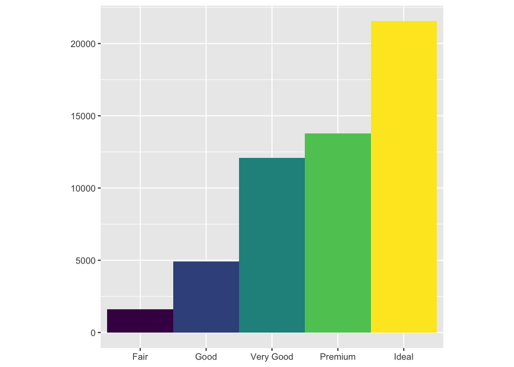

```r
bar
```

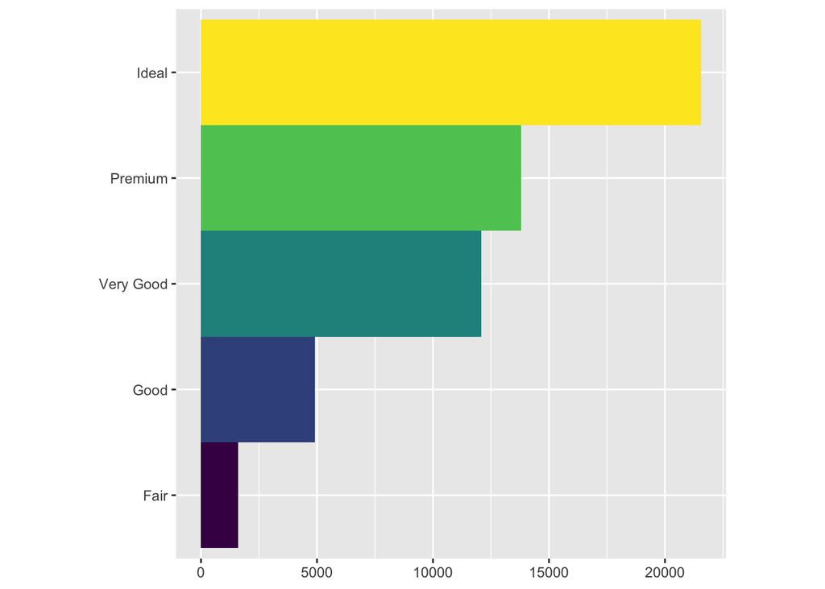

```r
bar + coord_flip()
```

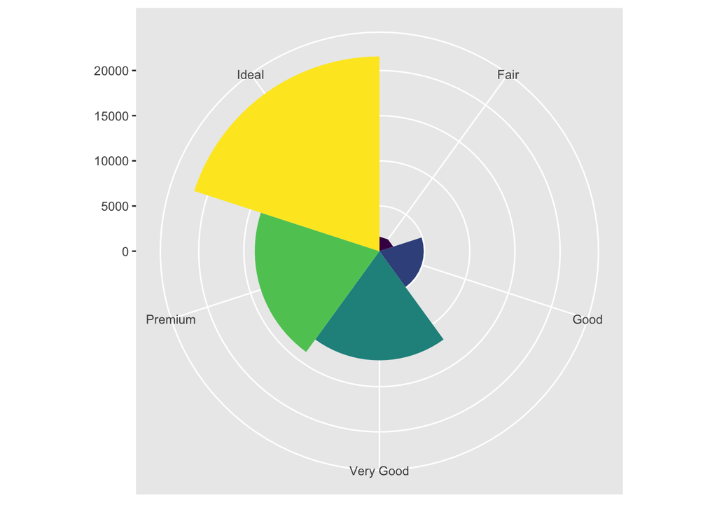

```r
bar + coord_polar()
```

## współrzędne w kontekscie map

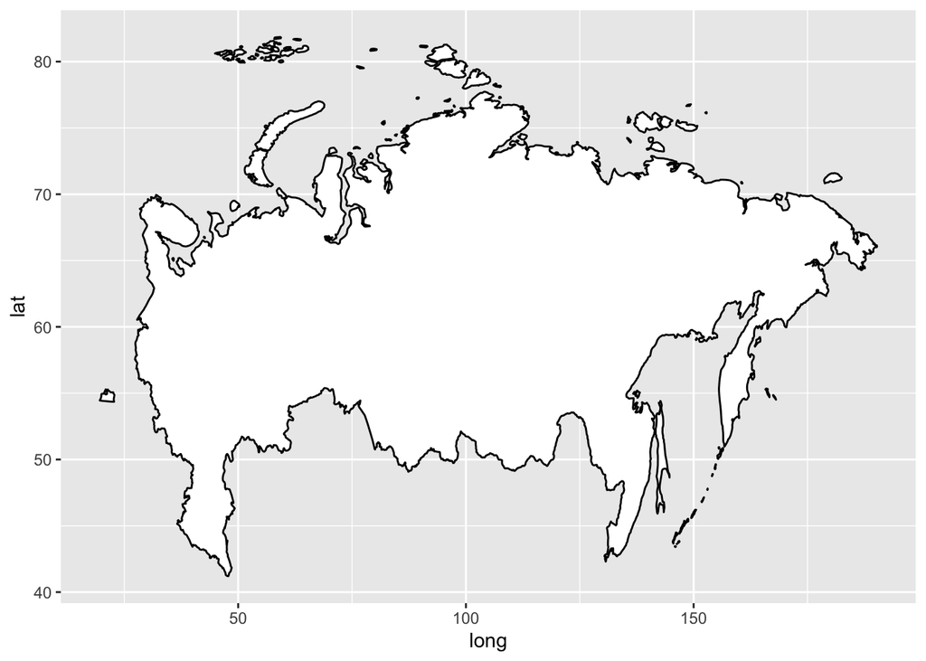

```r
ggplot( map_data("world", region = 'Russia'),
        aes(long, lat, group = group)) +
  geom_polygon(fill = "white",
               color = "black")
```

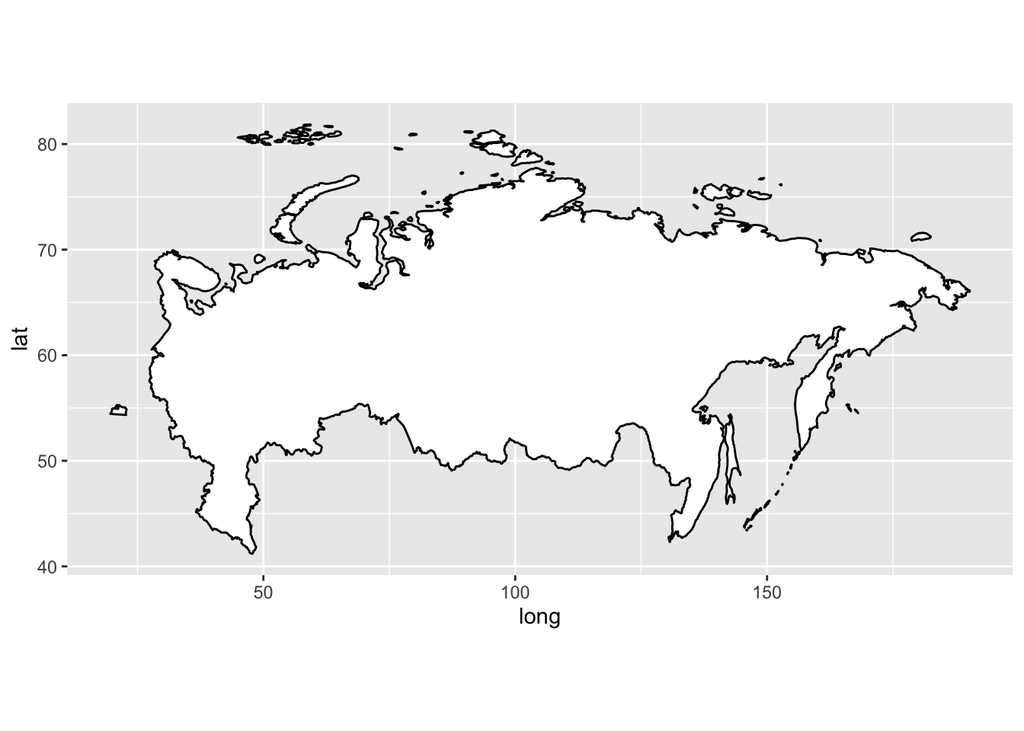

```r
ggplot(map_data("world",
                region = 'Russia'),
       aes(long,
           lat,
           group = group)) +
  geom_polygon(fill = "white",
               color = "black") +
  coord_quickmap()
```

## skale

### kolor

Lolorom poświęcimy więcej miejsca w przyszłości, w tym momencie tylko kilka przykładów

scale_color scale_color_brewer() RColorBrewer::display.brewer.all()

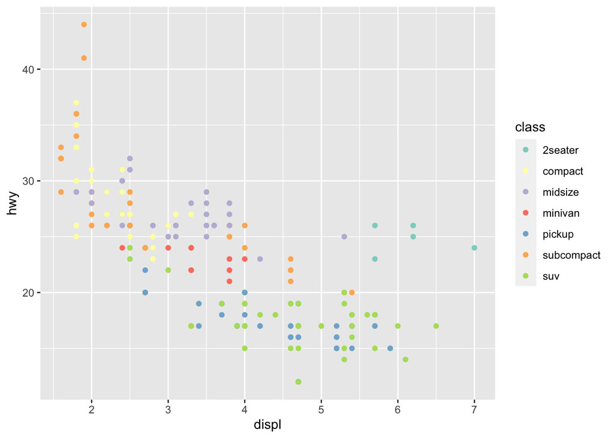

```r
ggplot(data = mpg) +
  geom_point( mapping = aes(x = displ, y = hwy, color = class)) +
  scale_color_brewer(palette ="Set3") # zmienia z domyślnego koloru na wybraną skalę  paletę
```

### osie

?scale_x_continuous()

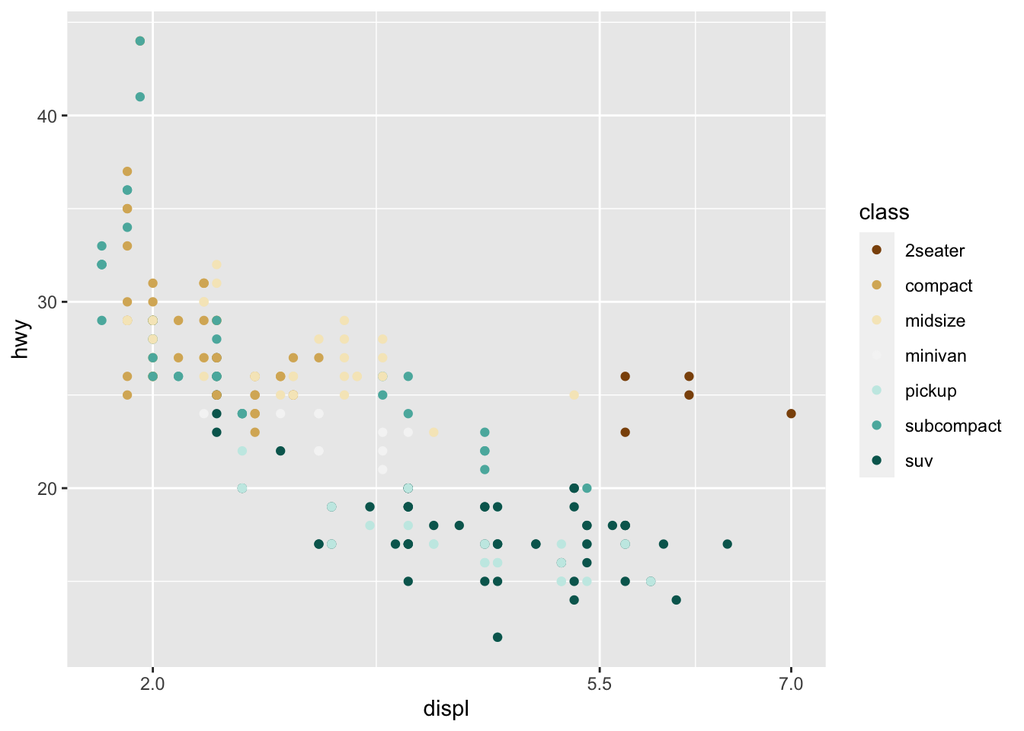

```r
ggplot(mpg) +
  geom_point(aes(x = displ, y = hwy, color = class)) +
  scale_color_brewer(palette ="BrBG") +
  scale_x_continuous(breaks = (c(2, 5.5, 7))) # ustalamy własne przedziały tworząc wektor liczb funkcją c()
```

#### zadanie - zastosujmy scale_x_discrete do danych mpg

?scale_x_discrete()

## panele - facets

Pozwalają uniknąć overplotting a także lepiej dostrzec pewne zależności w danych

porównajmy:

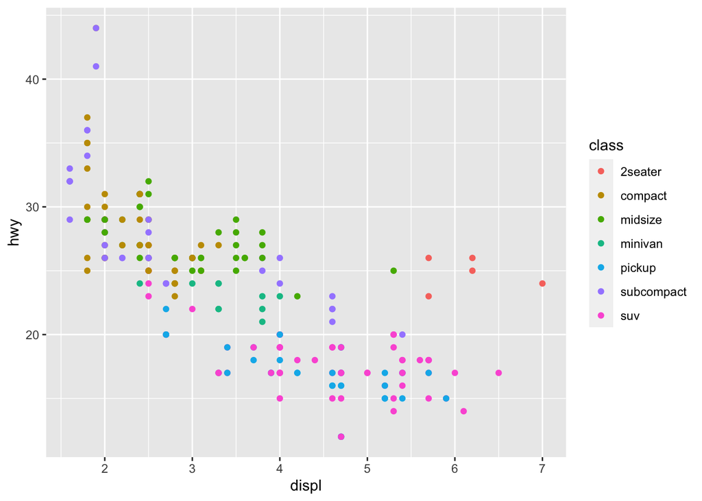

```r
ggplot(data = mpg) +
  geom_point(mapping = aes(x = displ, y = hwy, colour = class))
```

z poniższym wykresem:

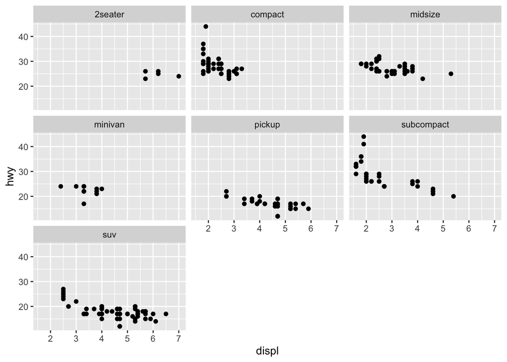

```r
ggplot(data = mpg) +
  geom_point(mapping = aes(x = displ, y = hwy)) +
  facet_wrap(~ class)
```

facet_wrap() mapuje jedną zmienną na panele

## mapowanie interakcji dwóch zmiennych na panele funkcją facet_grid()

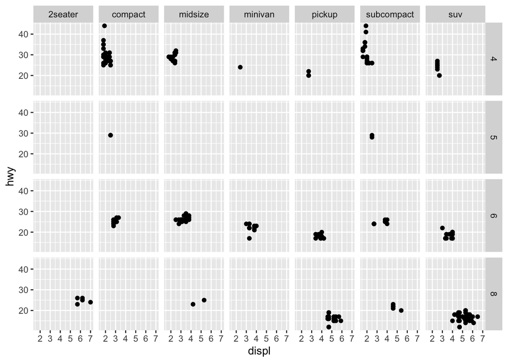

```r
ggplot(data = mpg) +
  geom_point(mapping = aes(x = displ,
                           y = hwy))  +
  facet_grid(cyl ~ class)
```

## etykiety

3etykiety dodajemy funkcją labs

labs(title = ““) # dodaje tytuł

labs(subtitle = ““) # dodaje podtytuł

labs(x = ““, y =”“, colour =”“) # zastepuje tytuły osi i w legendzie

Dodajmy tytuł i podpis pod wykresem:

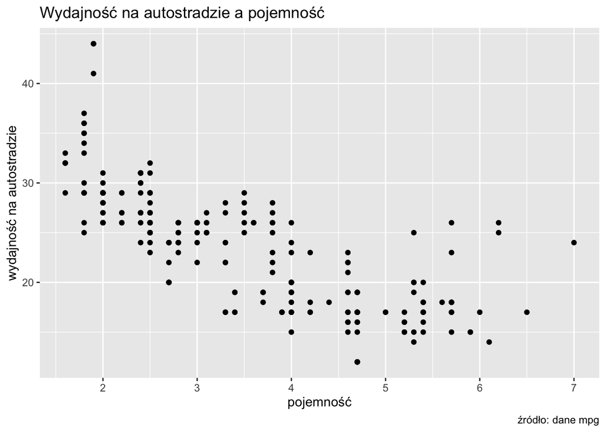

```r
ggplot(data = mpg) +
  geom_point(mapping = aes(x = displ, y = hwy)) +
  labs(title = "Wydajność na autostradzie a pojemność",
       caption = "źródło: dane mpg",
       x = "pojemność",
       y = "wydajność na autostradzie",
       colour = "klasa")
```

# zapisywanie

ggsave(“my-plot.pdf”) # > zapisue 6 x 3.71 cali

?ggsave # charakterystki wykresu w pliku docelowym i miejsce zapisania wykresu można ustalić

```r
ggsave("rys 1.pdf",
       plot = wykres,
       device=cairo_pdf, #cairo_pdf jest jednym z urządzeń (device) zapisujących wykres do właściwego formatu, zapewnia właściwe wyświetlenie polskich znaków
       width = 6,
       height=6,
       dpi = 300,
       units = "in",
       #path = ) # tu podajemy ścieżkę do folderu gdzie ma zostać zapisany plik
```

getwd() # zwraca aktualny katalog roboczy (working directory)

setwd() # determinuje aktualny katalog roboczy (working directory)

## themes - layouty

ggplot zawiera wiele własnych szablonów istnieją także pakiety zawierające dodatkowe layouty jak ggthemes

```r
#install.packages("ggthemes")
library(ggthemes)
```

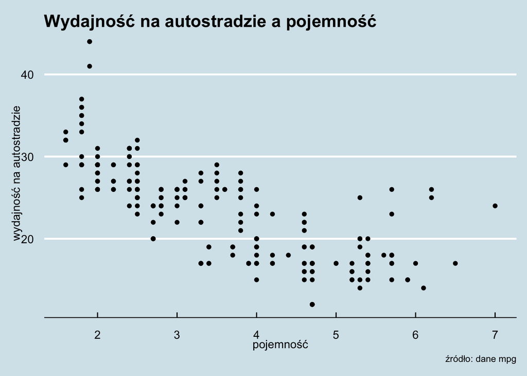

```r
ggplot(data = mpg) +
  geom_point(mapping = aes(x = displ, y = hwy)) +
  labs(title = "Wydajność na autostradzie a pojemność",
       caption = "źródło: dane mpg",
       x = "pojemność",
       y = "wydajność na autostradzie",
       colour = "klasa") + # theme jest kolejną warstwą którą dodajemy plusem
       theme_economist()
```